# intro to viz

Charles Lang

September 26, 2019

#Input

```r
D1 <- read.csv("School_Demographics_and_Accountability_Snapshot_2006-2012.csv", header = TRUE, sep = ",")

#Create a data frame only contains the years 2011-2012
library(dplyr)
D2 <- filter(D1, schoolyear == 20112012)
```

#Histograms

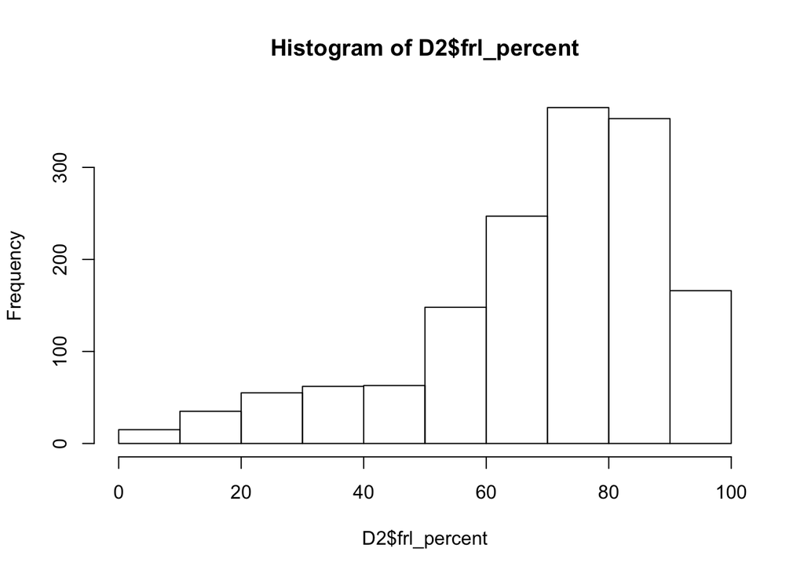

```r
#Generate a histogramof the percentage of free/reduced lunch students (frl_percent) at each school

hist(D2$frl_percent)
```

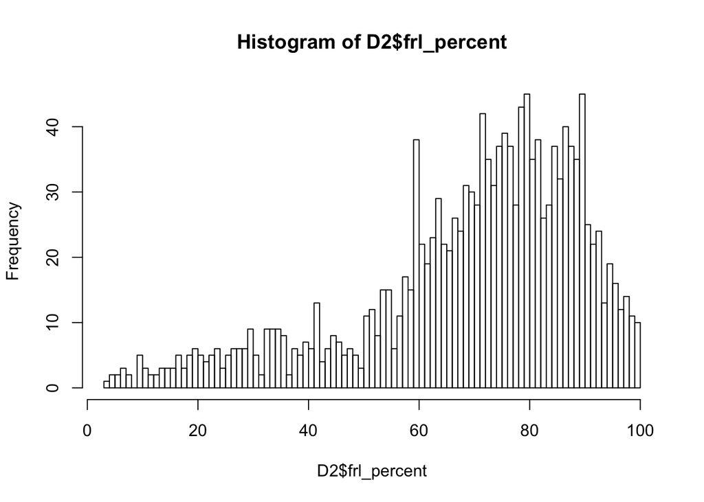

```r
#Change the number of breaks to 100, do you get the same impression?

hist(D2$frl_percent, breaks = 100)
```

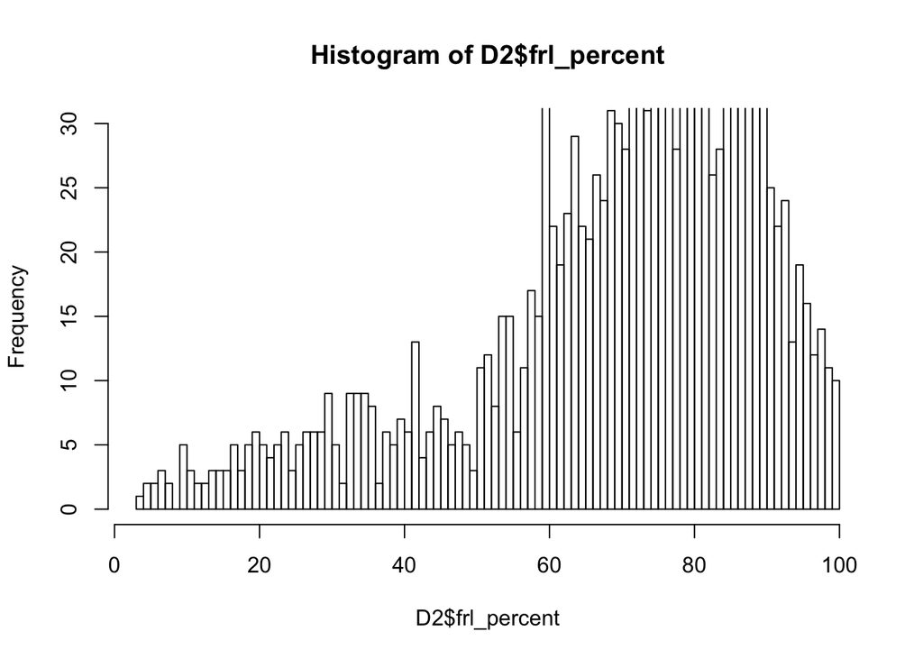

```r
#Cut the y-axis off at 30

hist(D2$frl_percent, breaks = 100, ylim = c(0,30))
```

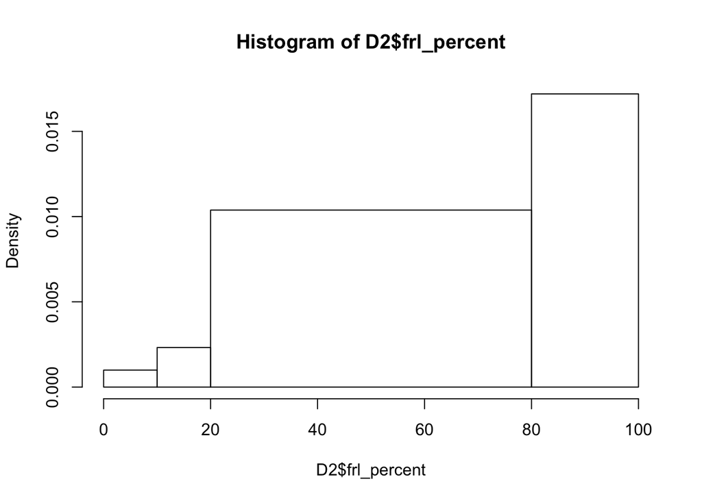

```r
#Restore the y-axis and change the breaks so that they are 0-10, 10-20, 20-80, 80-100

hist(D2$frl_percent, breaks = c(0,10,20,80,100))
```

#Plots

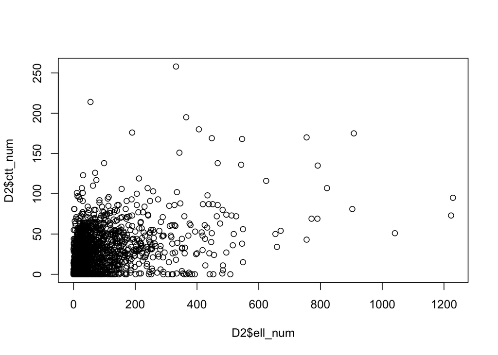

```r
#Plot the number of English language learners (ell_num) by Computational Thinking Test scores (ctt_num)

plot(D2$ell_num, D2$ctt_num)
```

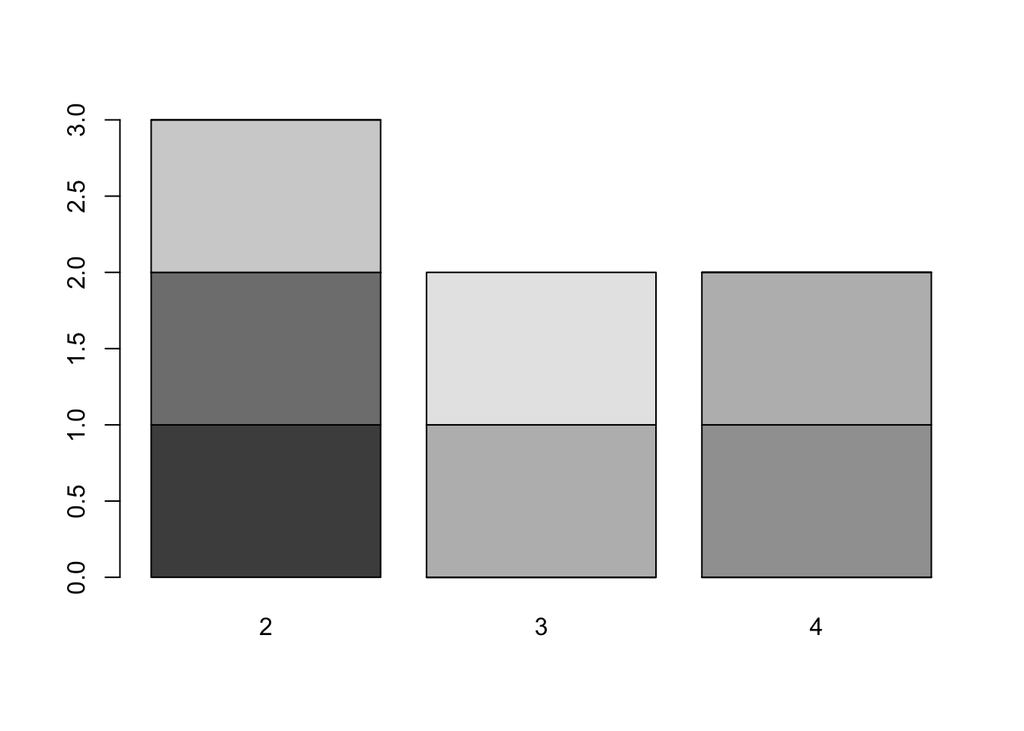

```r
#Create two variables x & y
x <- c(1,3,2,7,6,4,4)
y <- c(2,4,2,3,2,4,3)

#Create a table from x & y
table1 <- table(x,y)

#Display the table as a Barplot
barplot(table1)
```

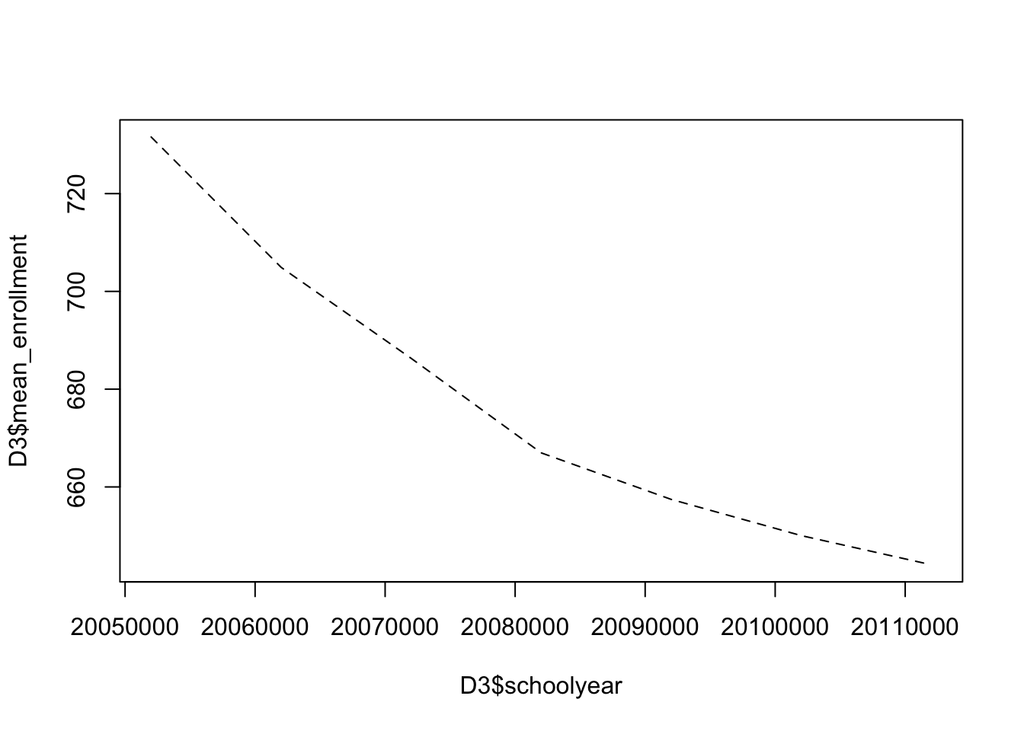

```r
#Create a data frame of the average total enrollment for each year and plot the two against each other as a lines

library(tidyr)
D3 <- D1 %>% group_by(schoolyear) %>% summarise(mean_enrollment = mean(total_enrollment))

plot(D3$schoolyear, D3$mean_enrollment, type = "l", lty = "dashed")
```

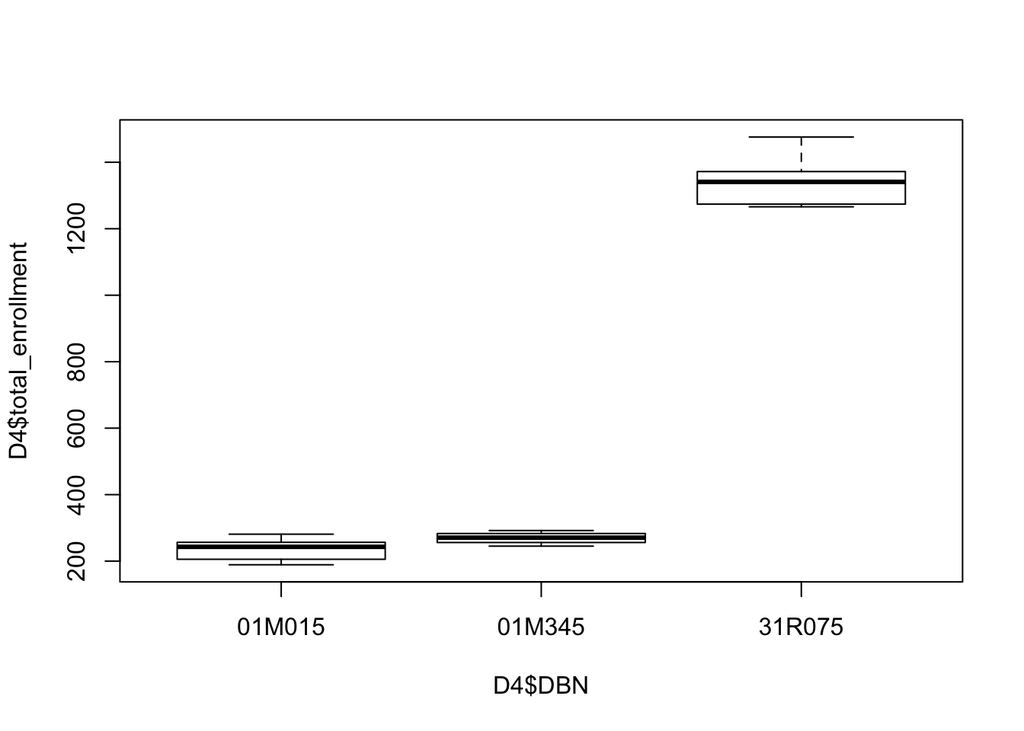

```r
#Create a boxplot of total enrollment for three schools
D4 <- filter(D1, DBN == "31R075"|DBN == "01M015"| DBN == "01M345")
#The drop levels command will remove all the schools from the variable with not data
D4 <- droplevels(D4)
boxplot(D4$total_enrollment ~ D4$DBN)
```

#Pairs

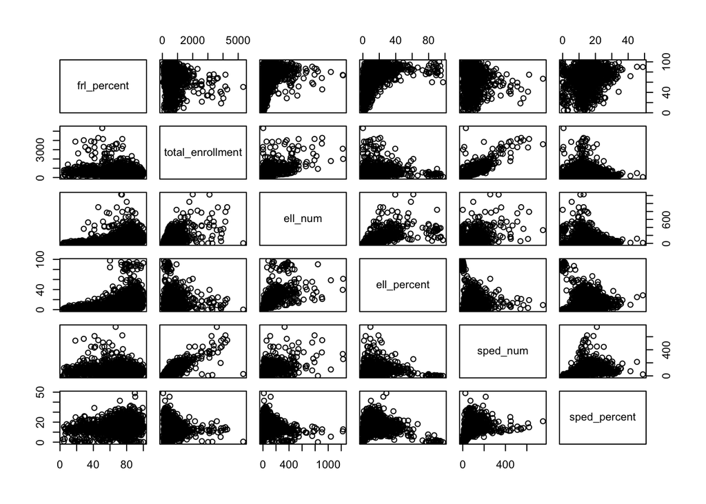

```r
#Use matrix notation to select columns 5,6, 21, 22, 23, 24
D5 <- D2[,c(5,6, 21:24)]
#Draw a matrix of plots for every combination of variables
pairs(D5)
```

# Exercise

1. Create a simulated data set containing 100 students, each with a score from 1-100 representing performance in an educational game. The scores should tend to cluster around 75. Also, each student should be given a classification that reflects one of four interest groups: sport, music, nature, literature.

```r
#rnorm(100, 75, 20) creates a random sample with a mean of 75 and standard deviation of 20
#pmax sets a maximum value, pmin sets a minimum value
#round rounds numbers to whole number values
#sample draws a random samples from the groups vector according to a uniform distribution
score<-rnorm(100,75,20)
score<-pmax(score,1)
score<-pmin(score,100)
score<-round(score,0)
interest<-sample(c("sport","music","nature","literature"),100,replace=TRUE)
student<-list(score=score,interest=interest) #list
#matrix
student_score<-rbind(score,interest)
colnames(student_score)<-c(1:100)
#data frame
df<-data.frame(score,interest)
```

2. Using base R commands, draw a histogram of the scores. Change the breaks in your histogram until you think they best represent your data.

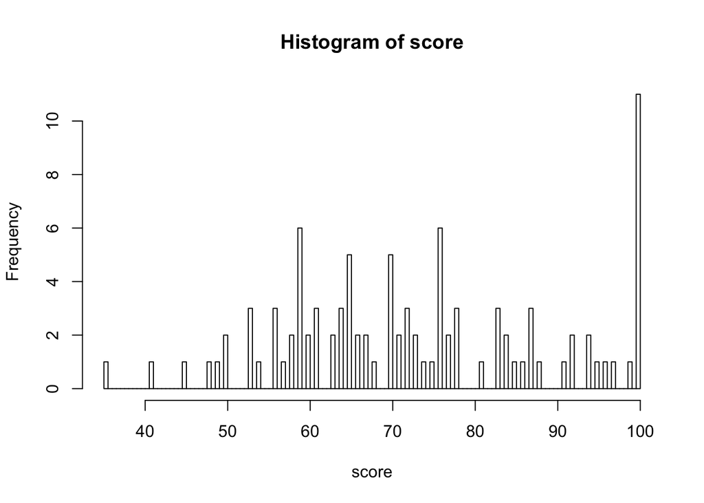

```r
hist(score,breaks = 100)
```

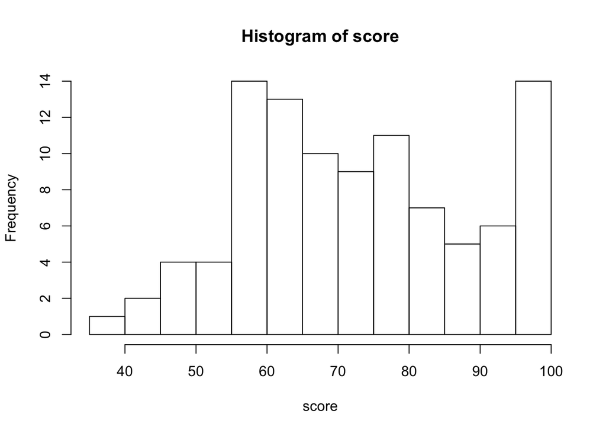

```r
hist(score,breaks=10)
```

3. Create a new variable that groups the scores according to the breaks in your histogram.

```r
#cut() divides the range of scores into intervals and codes the values in scores according to which interval they fall. We use a vector called `letters` as the labels, `letters` is a vector made up of the letters of the alphabet.
br<-c(-1,59,70,80,90,100)
letters<-c("F","D",'C','B','A')
grade<-table(cut(score,br,letters))
grade_student<-cut(score,br,letters,order_result=TRUE)
df<-data.frame(score,grade_student)
df
```

```
##     score grade_student
## 1      56             F
## 2      96             A
## 3      65             D
## 4     100             A
## 5      57             F
## 6      41             F
## 7      70             D
## 8      70             D
## 9      83             B
## 10     70             D
## 11     49             F
## 12     65             D
## 13     35             F
## 14     56             F
```

[output cut: 86 more lines]

```r
#cut score (ranking students score)
#cut(score,break=5,labels="E","D","C","B","A")
```

4. Now using the colorbrewer package (RColorBrewer) design a pallette and assign it to the groups in your data on the histogram.

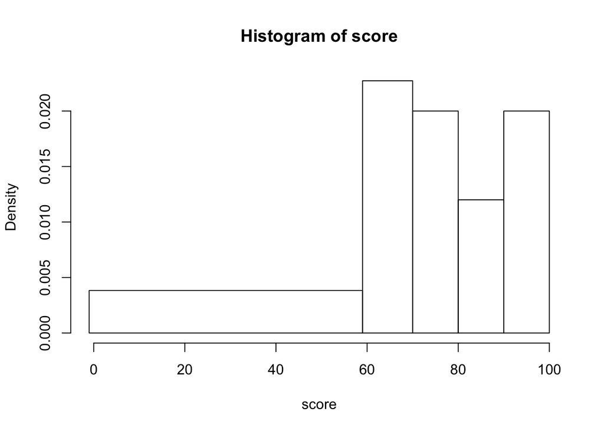

```r
library(RColorBrewer)
#Let's look at the available palettes in RColorBrewer

#The top section of palettes are sequential, the middle section are qualitative, and the lower section are diverging.r
#Make RColorBrewer palette available to R and assign to your bins

#Use named palette in histogram
hist(score,c(-1,59,70,80,90,100),right=TRUE)
graph<-hist(score,c(-1,59,70,80,90,100),right=TRUE)
```

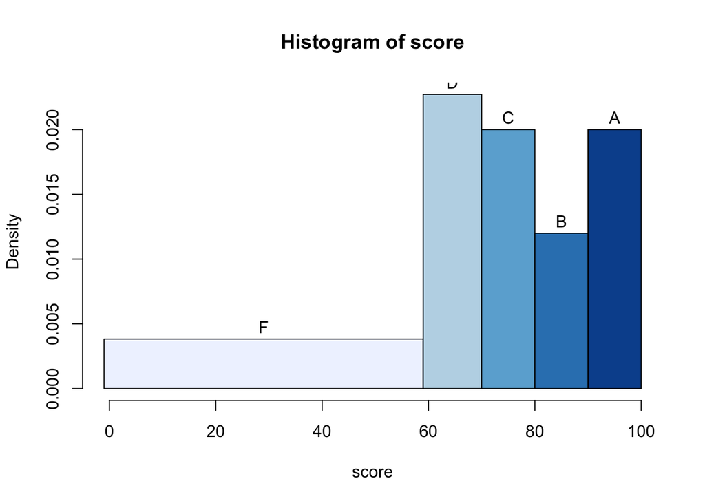

```r
plot(graph,labels=c("F","D","C","B","A"),col=brewer.pal(5,"Blues"))
```

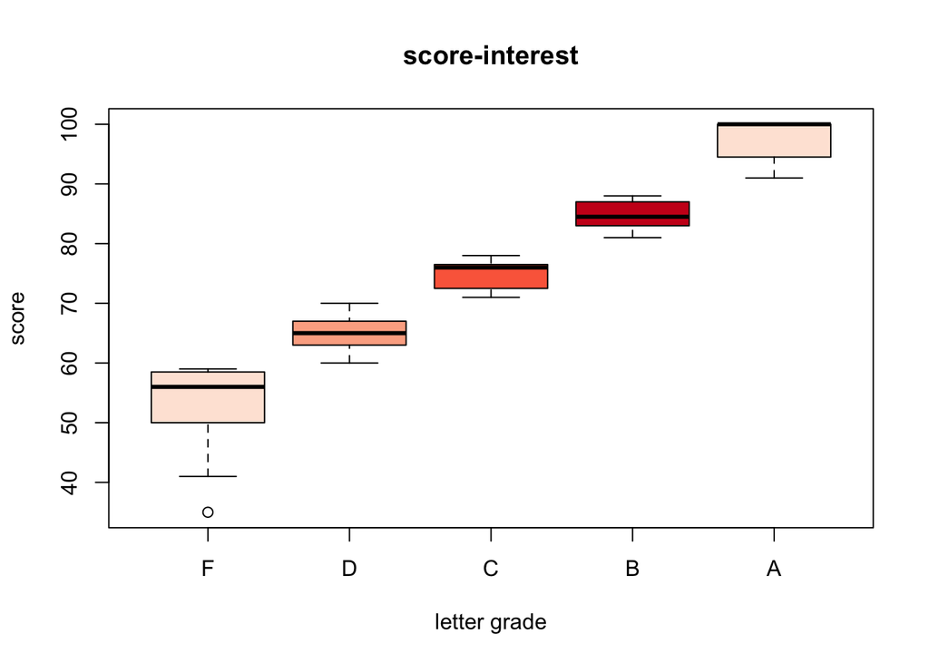

```r
#Make a vector of the colors from RColorBrewer
color<-brewer.pal(4,"Reds")
boxplot(score~grade_student,data=df,xlab="letter grade",ylab="score",main="score-interest",col=color)
```

6. Now simulate a new variable that describes the number of logins that students made to the educational game. They should vary from 1-25.

```r
game<-sample(1:25,100,replace=TRUE)
```

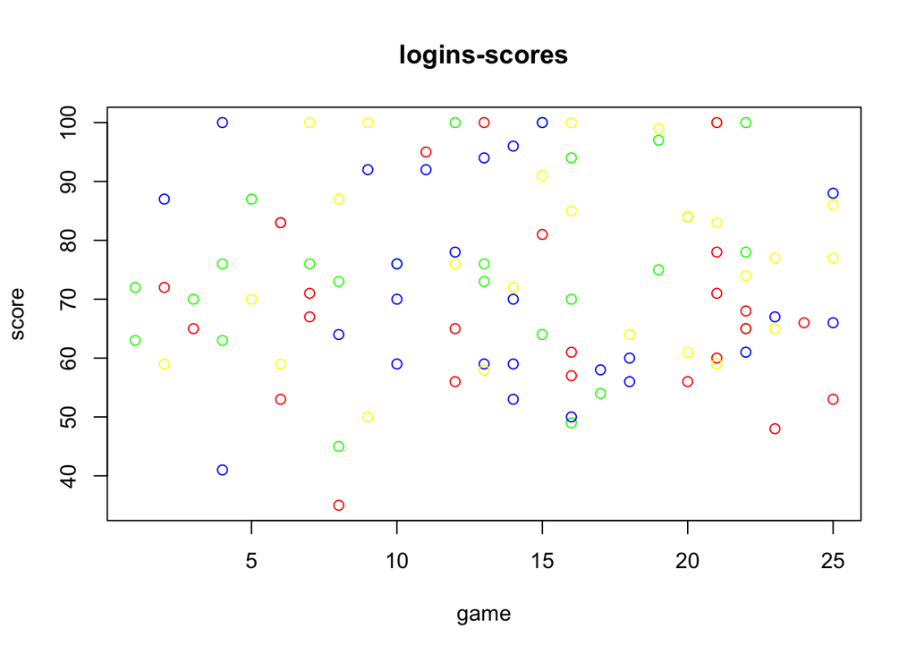

```r
plot(game,score,main="logins-scores",col=c("red","blue","green","yellow"))
```

8. R contains several inbuilt data sets, one of these in called AirPassengers. Plot a line graph of the the airline passengers over time using this data set.

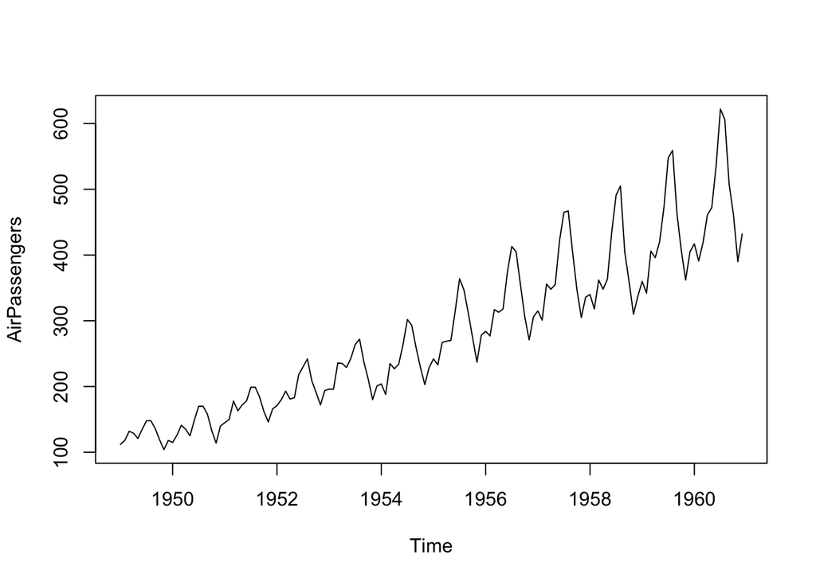

```r
plot(type="l",AirPassengers)
```

9. Using another inbuilt data set, iris, plot the relationships between all of the variables in the data set. Which of these relationships is it appropraiet to run a correlation on?

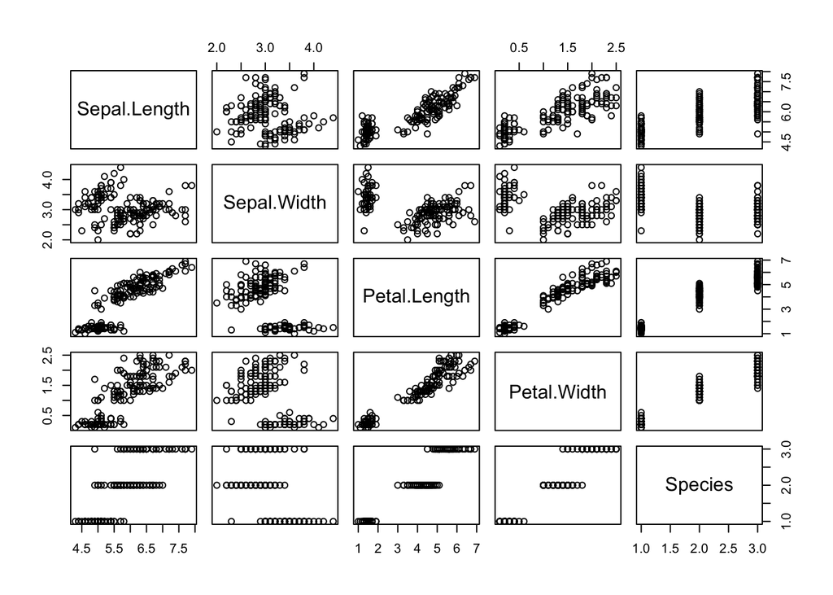

```r
#Sepal.Length & Sepal.Width & Petal.Length & Petal.Width these four factors
plot(iris)
```

10. Finally use the knitr function to generate an html document from your work. If you have time, try to change some of the output using different commands from the RMarkdown cheat sheet. install.packages(“knitr”)
11. Commit, Push and Pull Request your work back to the main branch of the repository